# Kimberly Pearson, MPA Candidate

Hi! My name is Kim Pearson and I am an MPA candidate at the University of Washington. I graduate this June with a focus in policy analysis. I studied Sustainability (Economics) and Spanish Literature and Culture at Arizona State University from 2008-2012. I am originally from Phoenix, AZ, which was a great place to learn about sustainability challenges and successes at the local level, especially in regards to climate, transportation, urban planning, and energy. I also spent time learning about social policy issues, such as immigration, civil rights, and labor. I came to the Evans School to learn quantitative and qualitative data analysis skills that can assist with social and environmental policy decision making at the local level.

## My Home Department

[Evans School of Public Policy & Governance](https://evans.uw.edu)

## Interest In The Course And What Scares You About It

I am very interested in this course because I would like to assist decision makers and analysts in understanding complex policy issues in areas like transportation, the environment, and social welfare. I took Visual Analytics with Professor Magallanes and really enjoyed learning the power of R to create helpful and impactful data graphics. I aim to apply these skills at the local government level, helping both internal and external stakeholders better understand and interact with key policy issues.

In terms of what scares me about the course, I want to make sure that I practice using R enough so that I can easily remember how to undertake key functionalities. I want to avoid falling out of practice from one week to the next.

## Three Things About Me

1. I have lived in several different places since undergrad at Arizona State University: Boulder, Colorado; Bocas del Toro, Panama; and now Seattle, WA.
2. I love to hike and go outside, especially to see all the moss, mushrooms, and flowers here in the Pacific Northwest! I am trying to learn how to identify different mushroom species.
3. I am an avid dancer, having learned salsa, bachata, and merengue. In Seattle, I am starting to learn Norwegian dancing, which doesn’t come as easily, but is incredibly rewarding once you get the steps right.

## Favorite Quote

> “If I can’t dance, I don’t want to be in your revolution.”
> - Emma Goldman

## Display Some Data

```r
link='https://github.com/EvansDataScience/VisualAnalytics_2_tabularData/raw/master/data/eduwa.rda'
load(file=url(link))
data(eduwa)
```

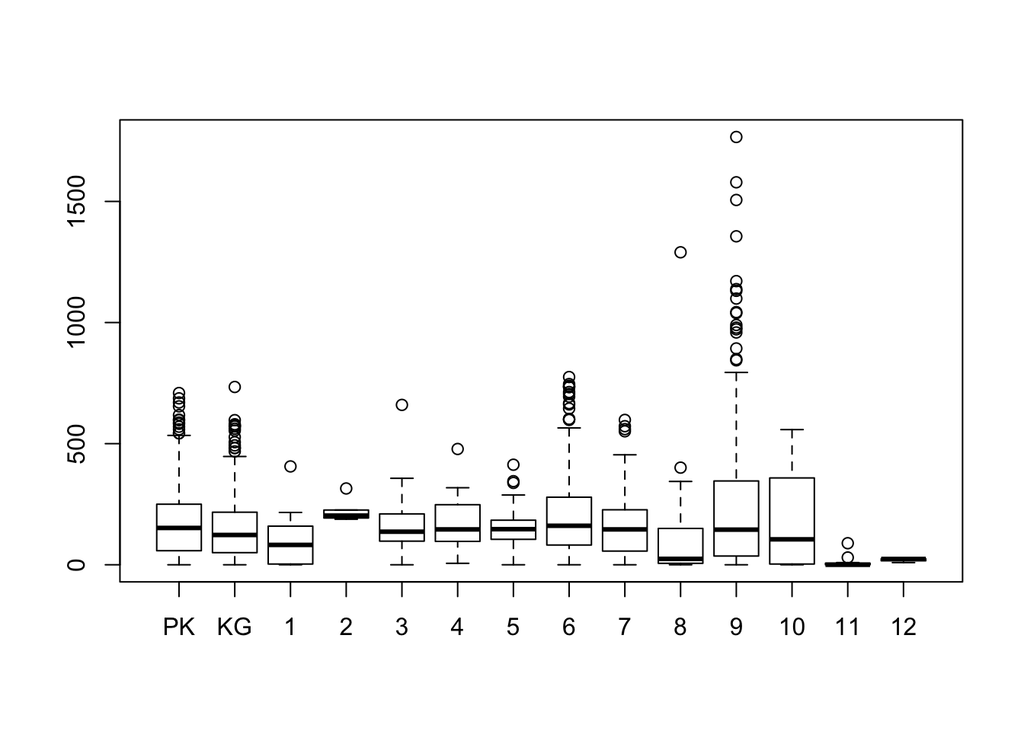

```r
plot(eduwa$Low.Grade, eduwa$Free.Lunch)
```